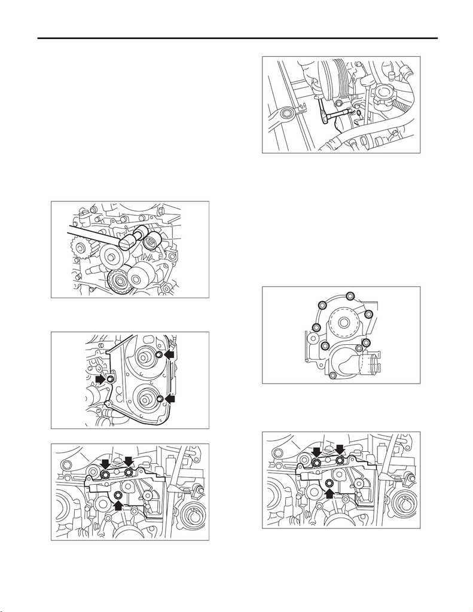

Water Pump

COOLING

4. Water Pump

A: REMOVAL

1) Remove the radiator. <Ref. to CO(STI)-19, RE-

MOVAL, Radiator.>

2) Remove the V-belts. <Ref. to ME(STI)-41, RE-

MOVAL, V-belt.>

3) Remove the crank pulley. <Ref. to ME(STI)-48,

REMOVAL, Crank Pulley.>

4) Remove the timing belt cover. <Ref. to ME(STI)-

50, REMOVAL, Timing Belt Cover.>

5) Remove the timing belt. <Ref. to ME(STI)-51,

REMOVAL, Timing Belt.>

6) Remove the automatic belt tension adjuster (A).

7) Remove the belt idler (B).

8) Remove the belt idler No. 2 (C).

9) Remove the cam sprocket LH. <Ref. to ME(STI)-

60, REMOVAL, Cam Sprocket.>

10) Remove the belt cover No. 2 LH.

11) Remove the tensioner bracket.

12) Disconnect the hose from water pump.

13) Remove the water pump.

B: INSTALLATION

1) Install the water pump onto cylinder block LH.

NOTE:

• Use a new gasket.

• When installing the water pump, tighten the bolts

in two stages in alphabetical sequence as shown in

figure.

Tightening torque:

First:

12 N·m (1.2 kgf-m, 8.9 ft-lb)

Second:

12 N·m (1.2 kgf-m, 8.9 ft-lb)

2) Install the hose to water pump.

3) Install the tensioner bracket.

Tightening torque:

24.5 N·m (2.5 kgf-m, 18.1 ft-lb)

CO-02726

(A)

(B)

(C)

CO-02908

ME-04984

CO-00021

ME-04743

(F)

(C)

(A)

(E)

(D)

(B)

ME-04984

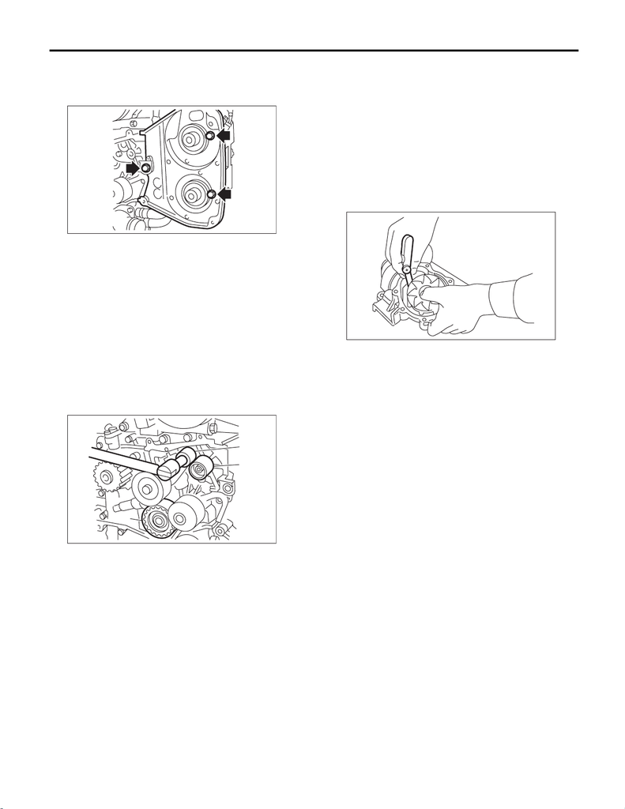

Water Pump

COOLING

4) Install the belt cover No. 2 LH.

Tightening torque:

5 N·m (0.5 kgf-m, 3.7 ft-lb)

5) Install the cam sprocket LH. <Ref. to ME(STI)-

60, INSTALLATION, Cam Sprocket.>

6) Install the belt idler No. 2 (C).

Tightening torque:

39 N·m (4.0 kgf-m, 28.8 ft-lb)

7) Install the belt idler (B).

Tightening torque:

25 N·m (2.5 kgf-m, 18.4 ft-lb)

8) Install the automatic belt tension adjuster (A)

with the tension rod held by a pin. <Ref. to

ME(STI)-53, AUTOMATIC BELT TENSION AD-

JUSTER ASSEMBLY AND BELT IDLER, INSTAL-

LATION, Timing Belt.>

9) Install the timing belt. <Ref. to ME(STI)-54, TIM-

ING BELT, INSTALLATION, Timing Belt.>

10) Install the timing belt cover. <Ref. to ME(STI)-

50, INSTALLATION, Timing Belt Cover.>

11) Install the crank pulley. <Ref. to ME(STI)-48,

INSTALLATION, Crank Pulley.>

12) Install the V-belts. <Ref. to ME(STI)-41, IN-

STALLATION, V-belt.>

13) Install the radiator. <Ref. to CO(STI)-20, IN-

STALLATION, Radiator.>

C: INSPECTION

1) Check the water pump bearing for smooth rota-

tion.

2) Check the water pump pulley for abnormalities.

3) Make sure the impeller is not abnormally de-

formed or damaged.

4) Inspect the clearance between impeller and

pump case.

Clearance between impeller and pump case:

Standard

0.5 — 1.5 mm (0.020 — 0.059 in)

5) After water pump installation, check pulley shaft

for engine coolant leaks or noise. If leaks or noise

are noted, replace the water pump assembly.

CO-02908

CO-02726

(A)

(B)

(C)

CO-00293